# projeto-final-mod-12

```python
%%html
<marquee style='width: 90%; color: blue;'><b>INSTITUTO INFNET | ESCOLA SUPERIOR DA
TECNOLOGIA DA INFORMAÇÃO</b></marquee>
```

**INSTITUTO INFNET | ESCOLA SUPERIOR DA TECNOLOGIA DA INFORMAÇÃO**

## Pós-graduação MIT em Inteligência Artificial, Machine Learning & Deep Learning

### Projeto da disciplina de Deep Learning com TensorFlow.

Bloco: Redes neurais com TensorFlow

Docente: Diego da Silva Rodrigues

Aluno: Winicius Botelho Faquieri

### Um modelo de Deep Neural Networks para classificação de estabelecimentos nos segmentos Autosserviço, Mercado Quente e Mercado Frio com diferentes funções de ativação

```python
# Imports:
import pandas as pd
import numpy as np
import seaborn as sns
import math
import inflection
from matplotlib import pyplot as plt
from IPython.core.display import HTML
from sklearn import model_selection as ms
from sklearn.preprocessing import RobustScaler
from sklearn.preprocessing import LabelEncoder
from sklearn.model_selection import KFold
from sklearn.model_selection import cross_val_score
from sklearn.metrics import multilabel_confusion_matrix
from sklearn.metrics import classification_report
from sklearn.metrics import confusion_matrix
from sklearn.metrics import roc_curve
from sklearn.metrics import roc_auc_score
from sklearn.ensemble import RandomForestRegressor
from keras.utils import np_utils
from keras.models import Sequential
from keras.layers import Dense
from keras.wrappers.scikit_learn import KerasClassifier
from keras.optimizers import SGD
```

- Problem and Data
- Feature Engineering
- Exploratory Data Analysis (EDA)
- Data Preparation
- Feature Selection
- The Model
- Results
- Conclusion
- References

## PROBLEM AND DATA

### Canais de distribuição - entendendo o problema

Objetivo: classificar empresas do varejo relativo ao mercado de bebidas frias em 03 segmentos ou canais de distribuição, a saber:

- Segmento I - Supermercados com 5 ou mais checkouts
- Segmento II - Supermercados com 4 ou menos checkouts (mercadinhos, mercearias, etc)
- Segmento III - Bares, restaurantes, padarias

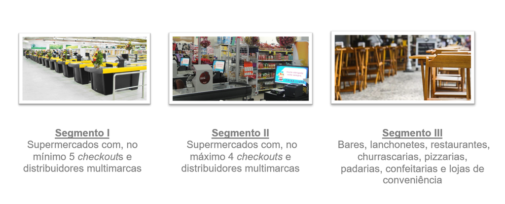

Neste notebook, um modelo de rede neural profunda é desenvolvido para classificar empresas do varejo em diferentes canais de distribuição. Existem 3 tipos de estabelecimento: varejo de autosserviço, mercado quente e mercado frio. Muitos experimentos foram feitos para o modelo com diferentes funções de ativação e para diferentes números de época.

O objetivo final é um modelo de aprendizado de máquina que possa prever a qual segmento pertence um dado estabelecimento. Além disso, queremos avaliar vários modelos antes de escolher um como o "melhor" e depois de construir um modelo, queremos investigar as previsões.

```python
# dataset
df = pd.read_csv('../data/features.csv', dtype=str)
```

Campos/colunas:

**NUM_DOC_DEST:** identificador dos estabelecimentos

**N_TRANS:** número de transações realizadas por estabelecimento ou cupom fiscal

**VAL_UNIT_MEDIO:** valor médio de compra

**VOLUME_COMPRA_MEDIO:** quantidade média de compras realizadas

**CESTA_PROD_DIFER:** diversidade de produtos comprados

Diferentes features foram utilizadas com o intuito de traçar um perfil de compra dos estabelecimentos.

```python
df.head()
```

|  | NUM_DOC_DEST | CNAE_DEST | N_TRANS | VAL_UNIT_MEDIO | VOLUME_COMPRA_MEDIO | CESTA_PROD_DIFER | GRUPO_PROD_DIFER | SEGMENTO | target |
| --- | --- | --- | --- | --- | --- | --- | --- | --- | --- |
| 0 | 12058181000196 | 4712100 | 668 | 5.460947248502994 | 146.9311377245509 | 62 | 17 | 2 | II |
| 1 | 93209765032582 | 4711301 | 3847 | 21.188510626992255 | 3171.2399272160123 | 266 | 36 | 1 | I |
| 2 | 13004510017235 | 4711302 | 8293 | 20.919979153356135 | 295.0801881104546 | 244 | 37 | 1 | I |
| 3 | 01031452000101 | 5611201 | 170 | 27.170852152941176 | 167.41176470588235 | 28 | 12 | 3 | III |
| 4 | 13964957000108 | 5611201 | 128 | 20.630893885416405 | 66.484375 | 36 | 18 | 3 | III |

```python
df.info()
```

```
<class 'pandas.core.frame.DataFrame'>
RangeIndex: 7726 entries, 0 to 7725
Data columns (total 9 columns):
 #   Column               Non-Null Count  Dtype
---  ------               --------------  -----
 0   NUM_DOC_DEST         7726 non-null   object
 1   CNAE_DEST            7726 non-null   object
 2   N_TRANS              7726 non-null   object
 3   VAL_UNIT_MEDIO       7726 non-null   object
 4   VOLUME_COMPRA_MEDIO  7726 non-null   object
 5   CESTA_PROD_DIFER     7726 non-null   object
 6   GRUPO_PROD_DIFER     7726 non-null   object
 7   SEGMENTO             7726 non-null   object
 8   target               7726 non-null   object
dtypes: object(9)
memory usage: 543.4+ KB
```

### Data Dimensions

```python
print( 'Number of Rows: {}'.format( df.shape[0] ) )
print( 'Number of Cols: {}'.format( df.shape[1] ) )
```

```
Number of Rows: 7726
Number of Cols: 9
```

### Data Types

```python
# Change data types
df['N_TRANS'] = df['N_TRANS'].astype( int )

# VAL_UN_COMPRA: VALOR UNITÁRIO PAGO PELA COMPRA
df['VAL_UNIT_MEDIO'] = df['VAL_UNIT_MEDIO'].astype( float )
df['VAL_UNIT_MEDIO'] = df['VAL_UNIT_MEDIO'].round(decimals = 2)

# VAL_BRUTO: VAL_UN_COMPRA X NUM_QTD_COMPRA
df['VOLUME_COMPRA_MEDIO'] = df['VOLUME_COMPRA_MEDIO'].astype( float )
df['VOLUME_COMPRA_MEDIO'] = df['VOLUME_COMPRA_MEDIO'].round(decimals = 2)

df['CESTA_PROD_DIFER'] = df['CESTA_PROD_DIFER'].astype( int )
df['GRUPO_PROD_DIFER'] = df['GRUPO_PROD_DIFER'].astype( int )

features = df.drop( ['CNAE_DEST','SEGMENTO'], axis=1 )

features.dtypes
```

```
NUM_DOC_DEST            object
N_TRANS                  int32
VAL_UNIT_MEDIO         float64
VOLUME_COMPRA_MEDIO    float64
CESTA_PROD_DIFER         int32
GRUPO_PROD_DIFER         int32
target                  object
dtype: object
```

### Check NA

```python
df.isna().sum()
```

```
NUM_DOC_DEST           0
CNAE_DEST              0
N_TRANS                0
VAL_UNIT_MEDIO         0
VOLUME_COMPRA_MEDIO    0
CESTA_PROD_DIFER       0
GRUPO_PROD_DIFER       0
SEGMENTO               0
target                 0
dtype: int64
```

### Descriptive statistics

```python
num_attributes = df.select_dtypes( include=['int32', 'float64'] )
cat_attributes = df.select_dtypes( exclude=['int32', 'float64','datetime64[ns]'] )
```

- Numerical atributes

```python
# Central Tendency - mean, meadina
ct1 = pd.DataFrame( num_attributes.apply( np.mean ) ).T
ct2 = pd.DataFrame( num_attributes.apply( np.median ) ).T

# dispersion - std, min, max, range, skew, kurtosis
d1 = pd.DataFrame( num_attributes.apply( np.std ) ).T
d2 = pd.DataFrame( num_attributes.apply( min ) ).T
d3 = pd.DataFrame( num_attributes.apply( max ) ).T
d4 = pd.DataFrame( num_attributes.apply( lambda x: x.max() - x.min() ) ).T
d5 = pd.DataFrame( num_attributes.apply( lambda x: x.skew() ) ).T
d6 = pd.DataFrame( num_attributes.apply( lambda x: x.kurtosis() ) ).T

# concatenar
m = pd.concat( [d2, d3, d4, ct1, ct2, d1, d5, d6] ).T.reset_index()
m.columns = ['attributes', 'min', 'max', 'range', 'mean', 'median', 'std','skew', 'kurtosis']
m
```

[output not shown]

## FEATURE ENGINEERING

**Hipóteses**:

- H1: VALOR UNITÁRIO MÉDIO DE COMPRA: É esperado um valor médio de compra maior em empresas do segmento 3 do que nos segmentos 1 e 2?
- H2. QUANTIDADE COMPRADA: É esperado um volume médio de compras maior por empresas do do varejo de autosserviço do que de outros segmentos?
- H3. CESTA DE PRODUTOS DIFERENTES: é esperado um mix de produtos maior no segmento 1 do que nos segmentos 2 e 3?
- H4. TRANSAÇÕES EFETUADAS: É esperado um número de transações realizadas ao longo do ano maior no segmento 1 do que em outros segmentos?

## EXPLORATY DATA ANALYSIS (EDA)

Objetivos:

- Validar hipóteses (insights)
- Perceber variáveis que são importantes para o modelo

### Distribuição da variável target

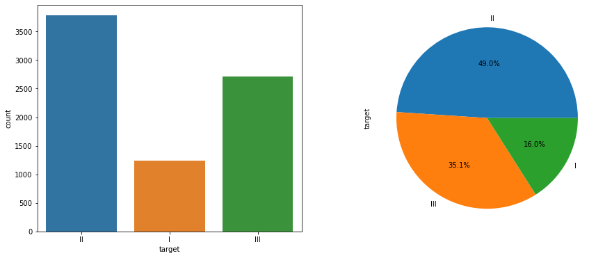

```python
features = df.copy()
fig, ax=plt.subplots(1,2,figsize=(15,6))
_ = sns.countplot(x='target', data=features, ax=ax[0])
_ = features['target'].value_counts().plot.pie(autopct="%1.1f%%", ax=ax[1])
```

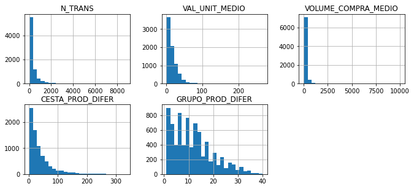

```python
plt.rcParams["figure.figsize"] = (800/72., 4.8)
num_attributes.hist( bins=25, layout=(2,3) );
```

- Análise bivariada:

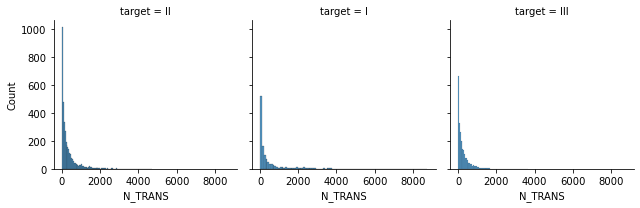

```python
g = sns.FacetGrid(features, col="target")
g.map(sns.histplot, "N_TRANS")
```

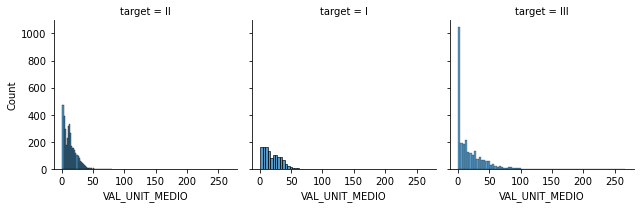

```python
g = sns.FacetGrid(features, col="target")
g.map(sns.histplot, "VAL_UNIT_MEDIO")
```

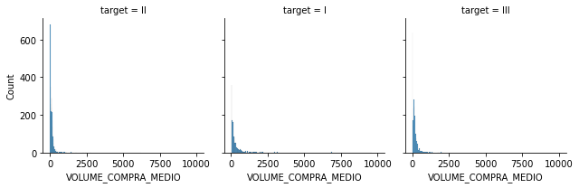

```python
g = sns.FacetGrid(features, col="target")
g.map(sns.histplot, "VOLUME_COMPRA_MEDIO")
```

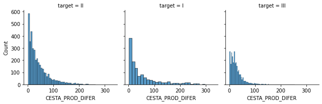

```python
g = sns.FacetGrid(features, col="target")
g.map(sns.histplot, "CESTA_PROD_DIFER")
```

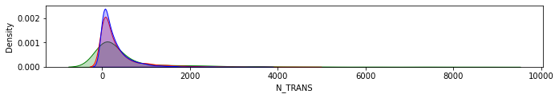

```python
plt.rcParams["figure.figsize"] = (800/72., 4.8)
plt.subplot( 3, 1, 1 )
sns.kdeplot( features[features['target'] == 'I']['N_TRANS'], label='SEGMENTO I', shade=True, color = 'green')
sns.kdeplot( features[features['target'] == 'II']['N_TRANS'], label='SEGMENTO II', shade=True, color = 'red' )
sns.kdeplot( features[features['target'] == 'III']['N_TRANS'], label='SEGMENTO III', shade=True, color = 'blue' )
```

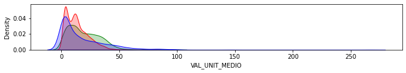

```python
plt.subplot( 3, 1, 1 )
sns.kdeplot( features[features['target'] == 'I']['VAL_UNIT_MEDIO'], label='SEGMENTO I', shade=True, color = 'green')
sns.kdeplot( features[features['target'] == 'II']['VAL_UNIT_MEDIO'], label='SEGMENTO II', shade=True, color = 'red' )
sns.kdeplot( features[features['target'] == 'III']['VAL_UNIT_MEDIO'], label='SEGMENTO III', shade=True, color = 'blue' )
```

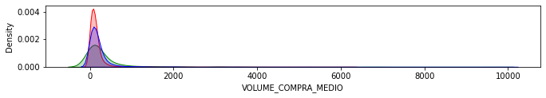

```python
plt.subplot( 3, 1, 1 )
sns.kdeplot( features[features['target'] == 'I']['VOLUME_COMPRA_MEDIO'], label='SEGMENTO I', shade=True, color = 'green' )
sns.kdeplot( features[features['target'] == 'II']['VOLUME_COMPRA_MEDIO'], label='SEGMENTO II', shade=True , color = 'red')
sns.kdeplot( features[features['target'] == 'III']['VOLUME_COMPRA_MEDIO'], label='SEGMENTO III', shade=True , color = 'blue')
```

[figure not shown]

```python
plt.subplot( 3, 1, 1 )
sns.kdeplot( features[features['seg'] == 'I']['CESTA_PROD_DIFER'], label='SEGMENTO I', shade=True, color = 'green')
sns.kdeplot( features[features['seg'] == 'II']['CESTA_PROD_DIFER'], label='SEGMENTO II', shade=True, color = 'red' )
sns.kdeplot( features[features['seg'] == 'III']['CESTA_PROD_DIFER'], label='SEGMENTO III', shade=True, color = 'blue' )
```

Vamos dar uma olhada nas correlações entre todas as variáveis domésticas. Se houver alguma que seja muito correlacionada, talvez queiramos remover um dos pares de variáveis altamente correlacionadas.

O código a seguir identifica quaisquer variáveis com uma correlação de magnitude absoluta maior que 0,95.

```python
# Create correlation matrix
corr_matrix = features.corr()


# Select upper triangle of correlation matrix
upper = corr_matrix.where(np.triu(np.ones(corr_matrix.shape), k=1).astype(np.bool))

# Find index of feature columns with correlation greater than 0.95
to_drop = [column for column in upper.columns if any(abs(upper[column]) > 0.95)]

to_drop
```

```
[]
```

```python
corr_matrix
```

|  | N_TRANS | VAL_UNIT_MEDIO | VOLUME_COMPRA_MEDIO | CESTA_PROD_DIFER | GRUPO_PROD_DIFER |
| --- | --- | --- | --- | --- | --- |
| N_TRANS | 1.000000 | -0.085480 | 0.142287 | 0.863847 | 0.720049 |
| VAL_UNIT_MEDIO | -0.085480 | 1.000000 | -0.135843 | -0.075298 | -0.045937 |
| VOLUME_COMPRA_MEDIO | 0.142287 | -0.135843 | 1.000000 | 0.118176 | 0.042943 |
| CESTA_PROD_DIFER | 0.863847 | -0.075298 | 0.118176 | 1.000000 | 0.909591 |
| GRUPO_PROD_DIFER | 0.720049 | -0.045937 | 0.042943 | 0.909591 | 1.000000 |

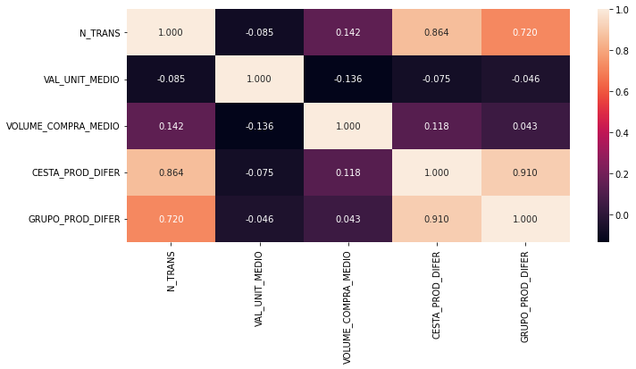

```python
sns.heatmap(corr_matrix, annot=True, fmt='.3f');
```

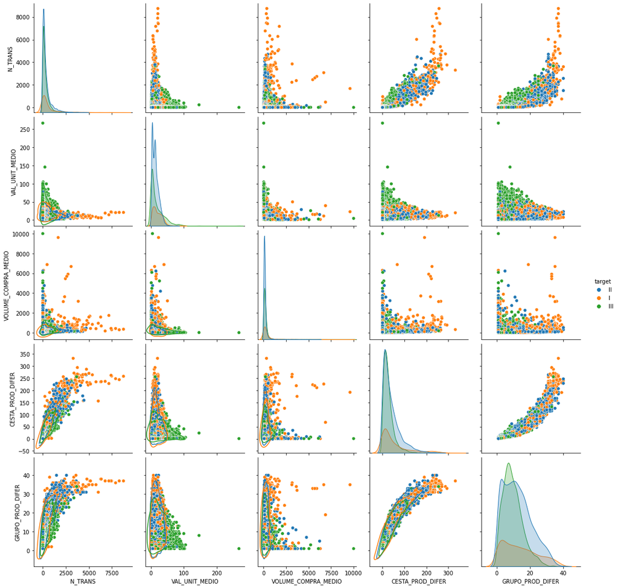

```python
# SCATTER PLOT
g = sns.pairplot(features, hue='target', height=3, diag_kind='kde')
_ = g.map_lower(sns.kdeplot, levels=1, color=".2")
```

### DATA PREPARATION

> O aprendizado da maioria dos algoritmos de ML é facilitado por dados numéricos, na mesma escala.
- Normalização: reescala o centro para zero com desvio-padrao igual a 1.
- Rescaling: reescala para o intervalo 0 e 1 (distribuições não Gaussianas):

```
- Min-Max Scaler: utiliza o range
- Robust Scaler: utiliza o IQR
```

- Transformação: conversão da feature categórica para numérica - encoding - e de natureza.

```python
features.describe().T
```

|  | count | mean | std | min | 25% | 50% | 75% | max |
| --- | --- | --- | --- | --- | --- | --- | --- | --- |
| N_TRANS | 7726.0 | 355.400595 | 599.943796 | 1.00 | 44.0000 | 155.000 | 406.0000 | 8752.00 |
| VAL_UNIT_MEDIO | 7726.0 | 16.001623 | 15.364872 | 0.57 | 3.8725 | 11.980 | 22.7025 | 266.99 |
| VOLUME_COMPRA_MEDIO | 7726.0 | 195.622875 | 425.267719 | 10.00 | 38.7600 | 109.605 | 189.8275 | 10000.00 |
| CESTA_PROD_DIFER | 7726.0 | 37.623350 | 41.603426 | 1.00 | 11.0000 | 24.000 | 48.0000 | 332.00 |
| GRUPO_PROD_DIFER | 7726.0 | 11.672405 | 8.056788 | 1.00 | 5.0000 | 10.000 | 16.0000 | 40.00 |

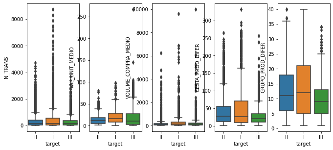

```python
fig, axs = plt.subplots(1,5)
sns.boxplot( x='target', y='N_TRANS', data=features, ax=axs[0] )
sns.boxplot( x='target', y='VAL_UNIT_MEDIO', data=features, ax=axs[1] )
sns.boxplot( x='target', y='VOLUME_COMPRA_MEDIO', data=features, ax=axs[2] )
sns.boxplot( x='target', y='CESTA_PROD_DIFER', data=features, ax=axs[3] )
sns.boxplot( x='target', y='GRUPO_PROD_DIFER', data=features, ax=axs[4] )
```

### Rescaling: Robust Scaler (RS)

Vamos utilizar o método RS devido a presença de valores atípicos.

```python
features2 = features.copy()
rs = RobustScaler()

features2['N_TRANS'] = rs.fit_transform( features2[['N_TRANS']].values )
features2['VAL_UNIT_MEDIO'] = rs.fit_transform( features2[['VAL_UNIT_MEDIO']].values )
features2['VOLUME_COMPRA_MEDIO'] = rs.fit_transform( features2[['VOLUME_COMPRA_MEDIO']].values )
features2['CESTA_PROD_DIFER'] = rs.fit_transform( features2[['CESTA_PROD_DIFER']].values )
features2['GRUPO_PROD_DIFER'] = rs.fit_transform( features2[['GRUPO_PROD_DIFER']].values )
```

```python
features2.describe().T
```

|  | count | mean | std | min | 25% | 50% | 75% | max |
| --- | --- | --- | --- | --- | --- | --- | --- | --- |
| N_TRANS | 7726.0 | 0.553593 | 1.657303 | -0.425414 | -0.306630 | 0.000000e+00 | 0.693370 | 23.748619 |
| VAL_UNIT_MEDIO | 7726.0 | 0.213575 | 0.815978 | -0.605948 | -0.430563 | 0.000000e+00 | 0.569437 | 13.542751 |
| VOLUME_COMPRA_MEDIO | 7726.0 | 0.569400 | 2.815084 | -0.659341 | -0.468963 | 4.703405e-17 | 0.531037 | 65.470038 |
| CESTA_PROD_DIFER | 7726.0 | 0.368199 | 1.124417 | -0.621622 | -0.351351 | 0.000000e+00 | 0.648649 | 8.324324 |
| GRUPO_PROD_DIFER | 7726.0 | 0.152037 | 0.732435 | -0.818182 | -0.454545 | 0.000000e+00 | 0.545455 | 2.727273 |

```python
# after rescaling
features2.head()
```

|  | NUM_DOC_DEST | CNAE_DEST | N_TRANS | VAL_UNIT_MEDIO | VOLUME_COMPRA_MEDIO | CESTA_PROD_DIFER | GRUPO_PROD_DIFER | SEGMENTO | target |
| --- | --- | --- | --- | --- | --- | --- | --- | --- | --- |
| 0 | 12058181000196 | 4712100 | 1.417127 | -0.346256 | 0.247075 | 1.027027 | 0.636364 | 2 | II |
| 1 | 93209765032582 | 4711301 | 10.198895 | 0.489113 | 20.266669 | 6.540541 | 2.363636 | 1 | I |
| 2 | 13004510017235 | 4711302 | 22.480663 | 0.474774 | 1.227762 | 5.945946 | 2.454545 | 1 | I |
| 3 | 01031452000101 | 5611201 | 0.041436 | 0.806691 | 0.382644 | 0.108108 | 0.181818 | 3 | III |
| 4 | 13964957000108 | 5611201 | -0.074586 | 0.459373 | -0.285468 | 0.324324 | 0.727273 | 3 | III |

```python
# before
features.head()
```

|  | NUM_DOC_DEST | CNAE_DEST | N_TRANS | VAL_UNIT_MEDIO | VOLUME_COMPRA_MEDIO | CESTA_PROD_DIFER | GRUPO_PROD_DIFER | SEGMENTO | target |
| --- | --- | --- | --- | --- | --- | --- | --- | --- | --- |
| 0 | 12058181000196 | 4712100 | 668 | 5.46 | 146.93 | 62 | 17 | 2 | II |
| 1 | 93209765032582 | 4711301 | 3847 | 21.19 | 3171.24 | 266 | 36 | 1 | I |
| 2 | 13004510017235 | 4711302 | 8293 | 20.92 | 295.08 | 244 | 37 | 1 | I |
| 3 | 01031452000101 | 5611201 | 170 | 27.17 | 167.41 | 28 | 12 | 3 | III |
| 4 | 13964957000108 | 5611201 | 128 | 20.63 | 66.48 | 36 | 18 | 3 | III |

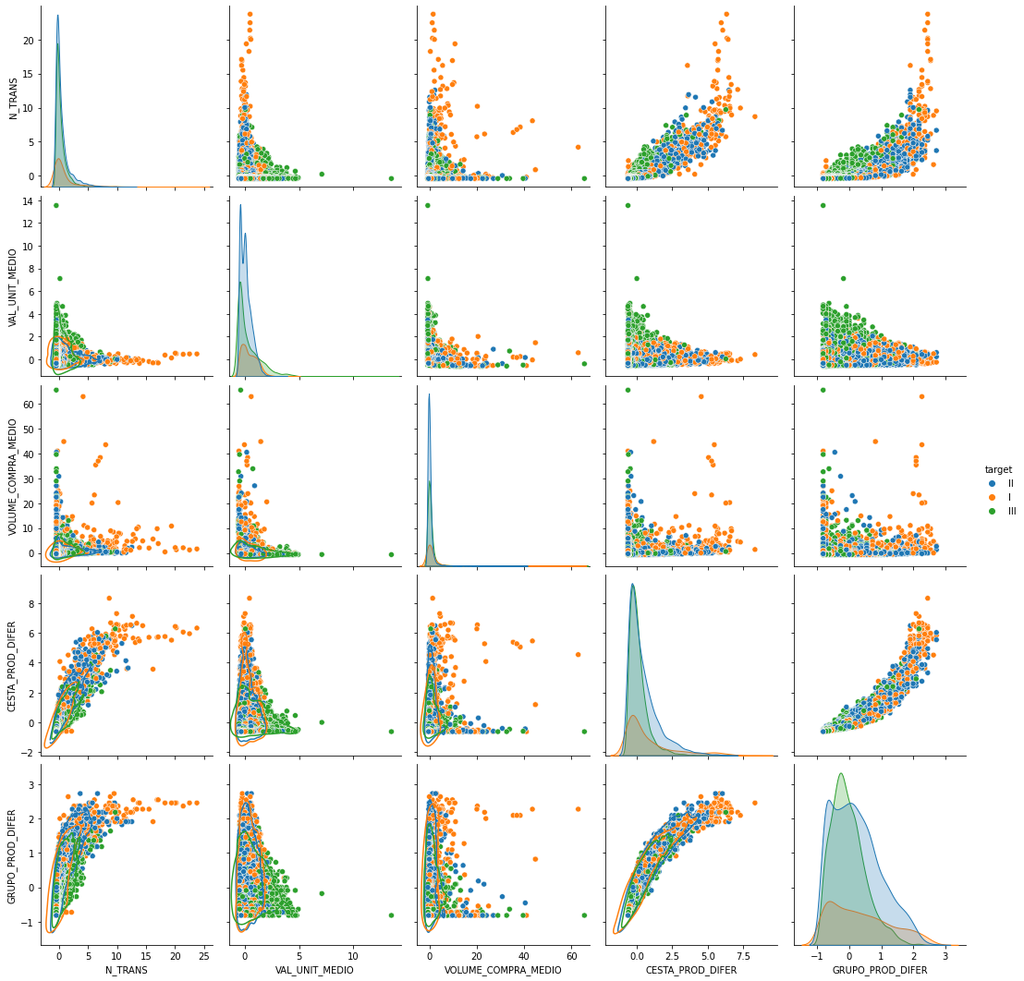

```python
g = sns.pairplot(features2, hue='target', height=3, diag_kind='kde')
_ = g.map_lower(sns.kdeplot, levels=1, color=".2")
```

### Encoding da variável categórica

```python
features3 = features2.copy()

# Segmento - Ordinal Encoding
segmento_dict = {'I': 1, 'II': 2, 'III': 3}
features3['target'] = features3['target'].map( segmento_dict );
```

```python
features3 = features3.drop( 'NUM_DOC_DEST', axis=1 )
```

### FEATURE SELECTION

> The process of reducing the number of input variables when developing a predictive model. It is desirable to reduce the number of input variables to both reduce the computational cost of modeling and, in some cases, to improve the performance of the model.

FILTER (before training) X WRAPPER (ocorre após o treinamento e utiliza as estatísticas geradas pelo próprio modelo)

- Análise estatítica
- Filter: Correlação, ANOVA.
- Wrapper: Árvores de decisão (entropia/**gini**), redes neurais (dropout/**relevância**)
- Correlação x Relevância
- Multicolinearidade -> Análise Discriminante Linear (LDA) ?

### Dividindo os dados em conjuntos de treinamento, teste e validação

#### Setup:

```
- Full data 100%
- test      20%  -> Generalization!
- training  80%, sendo 80% train + 20% validation -> Aprendizado!
```

```python
features4 = features3.drop( 'SEGMENTO', axis=1 )
features4.to_pickle('../data/features4.pickle')
```

```python
# features4 = pd.read_pickle('../data/features4.pickle')
```

```python
features4 = features4.drop( 'CNAE_DEST', axis=1 )

features4.dtypes
```

```
N_TRANS                float64
VAL_UNIT_MEDIO         float64
VOLUME_COMPRA_MEDIO    float64
CESTA_PROD_DIFER       float64
GRUPO_PROD_DIFER       float64
target                   int64
dtype: object
```

```python
class_col = 'target'
my_vars = list(features4.columns[features4.columns != class_col])
X = features4[my_vars]
X = np.asarray(X).astype('float32')

y = features4[[class_col]].values.ravel()

# encode class values as integers
encoder = LabelEncoder()
encoder.fit(y)
encoded_Y = encoder.transform(y)
# convert integers to dummy variables (i.e. one hot encoded)
dummy_y = np_utils.to_categorical(encoded_Y)
```

```python
# # # split training into train and test datset
X_train, X_test, y_train, y_test = ms.train_test_split(X, dummy_y, test_size=0.2, random_state=42)

print( X_train.shape, y_train.shape, X_test.shape, y_test.shape)
```

```
(6180, 5) (6180, 3) (1546, 5) (1546, 3)
```

```python
# the second split to create the final training set and the validation set:
X_train, X_val, y_train, y_val = ms.train_test_split(X_train, y_train, test_size=0.2, random_state=42)
```

# DNN Training

```python
# ==================== 1ª Epoca =======================
# foward: dados * pesos -> função de ativação -> predito
# real - predito = erro
# backpropagation: erro -> derivadas parciais -> update pesos

# ==================== 2ª Epoca =======================
# foward: dados * pesos -> função de ativação -> predito
# real - predito = erro
# backpropagation: erro -> derivadas parciais -> update pesos

# Até os pesos convergirem...
```

- Definindo o número de neurônios na hidden layer
1. O número de neurônios ocultos deve estar entre o tamanho da camada de entrada e o tamanho da camada de saída.
2. O número de neurônios ocultos deve ser 2/3 do tamanho da camada de entrada, mais o tamanho da camada de saída.
3. O número de neurônios ocultos deve ser menor que o dobro do tamanho da camada de entrada.

Essas três regras forneceram um ponto de partida. Em última análise, a seleção de uma arquitetura para sua rede neural se resume a tentativa e erro. Testamos, nesse sentido, várias combinações para chegarmos no melhor resultado. Além disso, o resultado de pesquisas anteriores em problemas similares serviu para nortear o trabalho. Mais especificamente, os trabalho de [ELDEM, A. (2020)](https://pdfs.semanticscholar.org/b08c/3940271a708e6dad8b915a65c36aa14713aa.pdf), [ELDEM et. al (2018)](https://ieeexplore.ieee.org/document/8620866), [Pinto, J. P., Kelur, S., & Shetty, J. (2018, October)](https://ieeexplore.ieee.org/abstract/document/9057891)

```python
# define baseline model:
model = Sequential()

# Add the first hidden layer
model.add(Dense(50, activation='relu', input_dim=5))

# Add the second hidden layer
model.add(Dense(20, activation='tanh'))

# Add the output layer
model.add(Dense(3, activation='softmax'))

# Compile the model
model.compile(optimizer='adam', loss='categorical_crossentropy', metrics=['accuracy'])
```

```python
model.summary()
```

```
Model: "sequential_2"
_________________________________________________________________
 Layer (type)                Output Shape              Param #
=================================================================
 dense_6 (Dense)             (None, 50)                300

 dense_7 (Dense)             (None, 20)                1020

 dense_8 (Dense)             (None, 3)                 63

=================================================================
Total params: 1,383
Trainable params: 1,383
Non-trainable params: 0
_________________________________________________________________
```

```python
# Train the model for many epochs
history = model.fit(X_train, y_train, validation_data=(X_test, y_test), batch_size=32, epochs=400, verbose=1)
```

### RESULTADOS

Vamos avaliar nosso modelo com base na **acurácia** e **matriz de confusão**.

```python
# Testing accuracy
scores = model.evaluate(X_train, y_train)
print("Training Accuracy: %.2f%%\n" % (scores[1]*100))

scores = model.evaluate(X_test, y_test)
print("Testing Accuracy: %.2f%%\n" % (scores[1]*100))
```

```
Training Accuracy: 69.30%

Testing Accuracy: 62.68%
```

```python
history_dict = history.history
loss_values = history_dict['loss']
val_loss_values = history_dict['val_loss']
acc_values = history_dict['accuracy']
val_acc_values = history_dict['val_accuracy']
epochs = range(1, len(val_loss_values) + 1)
```

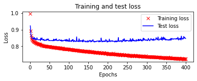

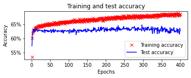

```python
import matplotlib.pyplot as plt
%matplotlib inline

plt.subplot(211)
plt.plot(epochs, history.history['loss'], 'rx', label='Training loss')
plt.plot(epochs, val_loss_values, 'b', label='Test loss')
plt.title('Training and test loss')
plt.xlabel('Epochs')
plt.ylabel('Loss')
plt.legend()
plt.show()

plt.subplot(212)
plt.plot(epochs, history.history['accuracy'], 'rx', label='Training accuracy')
plt.plot(epochs, val_acc_values, 'b', label='Test accuracy')
plt.title('Training and test accuracy')
plt.xlabel('Epochs')
plt.ylabel('Accuracy')
plt.gca().set_yticklabels(['{:.0f}%'.format(x*100) for x in plt.gca().get_yticks()])
plt.legend()
plt.show()
```

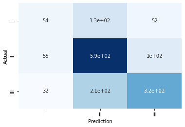

```python
# MATRIZ DE CONFUSÃO

predictions = model.predict(X_test)

c_matrix = confusion_matrix(np.argmax(y_test, axis=1), np.argmax(predictions, axis=1))
classification_report(np.argmax(y_test, axis=1), np.argmax(predictions, axis=1))

ax = sns.heatmap(c_matrix, annot=True,
                 xticklabels=['I','II','III'],
                 yticklabels=['I','II','III'],
                 cbar=False, cmap='Blues')
ax.set_xlabel("Prediction")
ax.set_ylabel("Actual")
```

```python
# TOP 10
results = pd.read_excel('../Tabela_Resultados.xlsx', sheet_name="4")
results.head(10)
```

|  | 1st_hidden_layer | 2nd_hidden_layer | epoch_number | accuracy_rate |
| --- | --- | --- | --- | --- |
| 0 | Relu | Tanh | 300 | 0.7000 |
| 1 | Tanh | Tanh | 400 | 0.6929 |
| 2 | Tanh | Tanh | 500 | 0.6700 |
| 3 | Relu | Tanh | 500 | 0.6700 |
| 4 | Relu | Tanh | 400 | 0.6600 |
| 5 | Tanh | Tanh | 300 | 0.6500 |
| 6 | Relu | Tanh | 200 | 0.6500 |
| 7 | Relu | Relu | 400 | 0.6500 |
| 8 | Relu | Relu | 100 | 0.6500 |
| 9 | Relu | Relu | 200 | 0.6500 |

### CONLUSÃO

Em seguida, analisamos a arquitetura do MLP que usamos, que consiste em 2 camadas ocultas, com 50 nós na primeira camada oculta e 20 nós na segunda camada oculta. Em seguida, implementamos esse MLP no Keras usando o modelo sequencial, que nos permite empilhar camadas umas sobre as outras. Então, treinamos nosso MLP usando o conjunto de treinamento, utiizando o algoritmo otimizador Adam para modificar os pesos e vieses na rede neural em mais de 200 iterações, melhorando gradualmente a precisão do modelo.

### REFERÊNCIAS

Eldem, A. (2020). An application of deep neural network for classification of wheat seeds. Avrupa Bilim ve Teknoloji Dergisi, (19), 213-220.

Loy, J. (2019). Neural Network Projects with Python: The ultimate guide to using Python to explore the true power of neural networks through six projects. Packt Publishing Ltd.

Eldem, A., Eldem, H., & Üstün, D. (2018, September). A model of deep neural network for iris classification with different activation functions. In 2018 International Conference on Artificial Intelligence and Data Processing (IDAP) (pp. 1-4). IEEE.

Pinto, J. P., Kelur, S., & Shetty, J. (2018, October). Iris flower species identification using machine learning approach. In 2018 4th International Conference for Convergence in Technology (I2CT) (pp. 1-4). IEEE.